# STATS 326/786

Week 1 Tutorial

> The National Basketball Association (NBA) is North America’s premier men’s professional basketball league. Data has been collected on 54 random NBA players. The following variables have been measured: height (in feet), weight (in pounds), fgp (field goal percentage), ftp (free-throw percentage), and ppg (average points-per-game).
> 1. Read in `basketball.csv` using `read_csv` and convert the data frame to a `tibble` object.

```r
data <- as_tibble(read_csv("basketball.csv"))
```

> 2. Use the `mutate` function to create the following new variables in your `tibble` object: height (in cm), weight (in kg), body-mass-index (BMI), and a binary indicator that determines if an NBA player is tall or short (where a player is classified as tall if they are taller than 6.5 ft).

The following conversions will help:

$$\begin{eqnarray*}
\text{height (m)} &=& \text{height (ft)} \times 0.3048 \\
\text{weight (kg)} &=& \text{weight (lb)} \times 0.45359237 \\
\text{bmi} &=& \frac{\text{weight (kg)}}{\text{height (m)}^2}
\end{eqnarray*}$$

Hint: The `ifelse` function may be useful for creating your binary indicator.

```r
data <- data |>
  mutate(height_m = height * 0.3048,
         weight_kg = weight / 2.204,
         bmi = weight_kg / height_m^2,
         tallshort = ifelse(height <= 6.5, "Short", "Tall")
         )

head(data)
```

```
## # A tibble: 6 × 9
##   height weight   fgp   ftp   ppg height_m weight_kg   bmi tallshort
##    <dbl>  <dbl> <dbl> <dbl> <dbl>    <dbl>     <dbl> <dbl> <chr>
## 1    6.8    225 0.442 0.672   9.2     2.07     102.   23.8 Tall
## 2    6.3    180 0.435 0.797  11.7     1.92      81.7  22.1 Short
## 3    6.4    190 0.456 0.761  15.8     1.95      86.2  22.7 Short
## 4    6.2    180 0.416 0.651   8.6     1.89      81.7  22.9 Short
## 5    6.9    205 0.449 0.9    23.2     2.10      93.0  21.0 Tall
## 6    6.4    225 0.431 0.78   27.4     1.95     102.   26.8 Short
```

> 3. Use the `group_by` and `summarise` functions to calculate the mean field goal percentage, free throw percentage, and points-per-game for short versus tall NBA players.

```r
data |>
  group_by(tallshort) |>
  summarise(mean_fgp = mean(fgp),
            mean_ftp = mean(ftp),
            mean_ppg = mean(ppg),
            n = n()
            )
```

```
## # A tibble: 2 × 5
##   tallshort mean_fgp mean_ftp mean_ppg     n
##   <chr>        <dbl>    <dbl>    <dbl> <int>
## 1 Short        0.427    0.757     12.9    26
## 2 Tall         0.470    0.727     10.8    28
```

> 4. Find the largest and smallest average points-per-game for tall versus short NBA players.
> 5. Use `ggplot` and `geom_point` to make a scatter plot of weight (in kg) by height (in m), and size by BMI. Use the `alpha` command add transparency. Comment on the plot.

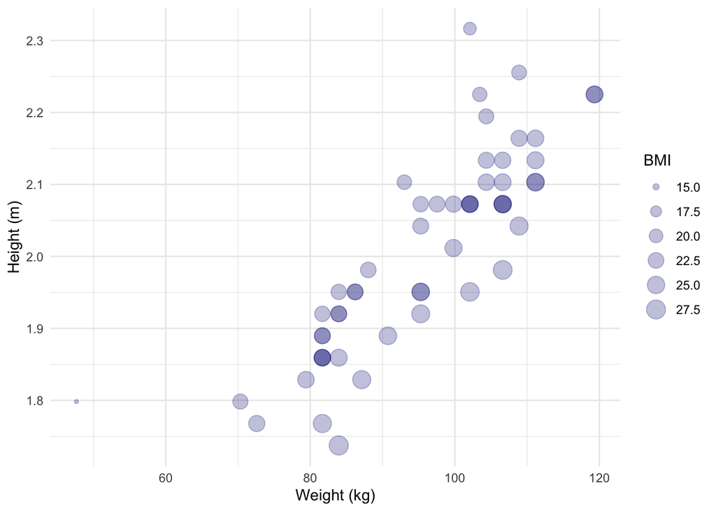

```r
data |> ggplot(aes(x = weight_kg,
                   y = height_m,
                   size = bmi)) +
  geom_point(col = "navy", alpha = 0.25) +
  labs(x = "Weight (kg)",
       y = "Height (m)",
       size = "BMI") +
  theme_minimal()
```

> 6. Use `ggplot` and `geom_point` to make a scatter plot of field goal percentage by average points-per-game, with short and tall NBA players on different panels. Comment on the plot.
> 7. Use `ggplot` and `geom_histogram` to make a histogram of average points-per-game, colouring by your binary height indicator. Use the `alpha` command to add transparency. Comment on the plot.
> 8. If you finish early, play around with other `geom` functions, `aes` mappings, as well as other `scale` and `theme` options.